# Block-Bootstrap Mann-Kendall Test Report

The **BB-MK Test** is used to assess whether there is a statistically significant monotonic trend in a time series.

Unlike the MK test, the BB-MK test is insensitive to autocorrelation.

- **Null Hypothesis**: There is no monotonic trend.
- **Alternative Hypothesis**: There is a monotonic upwards or downwards trend.

To carry out the BB-MK test, we rely on the results of the MK test and Spearman test.

1. Compute the MK test statistic.
2. Find the greatest significant lag $k$ using the Spearman test.
3. Resample from the original time series in blocks of size $k+1$, without replacement.
4. Estimate the MK test statistic for each bootstrapped sample.
5. Derive the empirical distribution of the MK test statistic from the bootstrapped statistics.
6. Estimate the significance of the observed test statistic using the empirical distribution.

## Results

### Code

```r
# Load auxillary tests
source("stats/mk/mk-test.R")
source("stats/spearman/spearman-test.R")

# Block-Bootstrap Mann-Kendall test for identifying non-autocorrelated trends
#  - ams: A vector of annual maximum streamflow data with no NA values
#  - alpha: The significance level as a floating point number
#  - reps: The number of repetitions for the bootstrap
bbmk_test <- function(ams, alpha = 0.05, reps = 10000) {

    # Assign a variable to the number of data points for convenience
    n <- length(ams)

    # Compute least_lag and s_statistic from the Spearman and MK tests
    least_lag <- spearman_test(ams, alpha)$least_lag
    s_statistic  <- mk_test(ams, alpha)$s_statistic

    # Create blocks
    block_size <- least_lag + 1
    n_blocks <- ceiling(n / block_size)
    blocks <- split(ams[1:(n_blocks * block_size)], rep(1:n_blocks, each = block_size))

    # Loop through the bootstrap
    s_bootstrap <- numeric(reps )
    for (sample in 1:reps ) {

        # Sample blocks for this iteration
        sampled_blocks <- sample(blocks, n_blocks, replace = FALSE)
        resampled_series <- unlist(sampled_blocks, use.names = FALSE)
        ams_resampled <- resampled_series[!is.na(resampled_series)]

        # Compute the Mann-Kendall statistic for this iteration
        s <- 0
        for (i in 1:(n-1)) {
            for (j in (i+1):n) {
                s = s + sign(ams_resampled[j] - ams_resampled[i])
            }
        }

        s_bootstrap[sample] = s
    }

    # Compute the p-value empirically using the bootstrap distribution
    p_value <- ifelse(
        s_statistic < 0,
        2 * mean(s_statistic >= s_bootstrap),
        2 * mean(s_statistic <= s_bootstrap)
    )

    # Compute the CI bounds
    bounds <- quantile(s_bootstrap, c(alpha / 2, 1 - (alpha / 2)))

    # Determine whether we reject or fail to reject based on p_value and alpha
    reject <- (p_value <= alpha)

    # Return the results as a list
    mget(c("s_bootstrap", "s_statistic", "p_value", "bounds", "reject"))

}
```

### Statistics

- S-statistic: -1398
- P-value: 0.218
- Significance level: 0.05
- Confidence bounds: -1882, 1678

Given the p-value and significance level, we FAIL TO REJECT the null hypothesis.

There is no evidence of a monotonic upwards or downwards trend.

### Figure

```r
library(ggplot2)

# Source the plot theme (path is relative to /source)
source("helpers/plot-theme.R")

# Plot the results of the Mann-Whitney-Pettitt test for abrupt changes in the mean
bbmk_plot <- function(df, results, show_trend) {

    # Load the results of the test into the environment
    list2env(results, envir = environment())

    # First subplot: Spearman's Rho Autocorrelation
    p1 <- ggplot() +
        geom_histogram(
            aes(x = s_bootstrap, color = "gray"),
            fill = "lightgray",
            bins = 30
        )  +
        geom_vline(aes(xintercept = bounds, color = "red"), linewidth = 1.2) +
        geom_vline(aes(xintercept = s_statistic, color = "black"), linewidth = 1.2) +
        labs(
            title = "Block-Bootstrap Mann-Kendall Test",
            x = "S-Statistic",
            y = "Frequency",
            color = "Legend"
        ) +
        scale_color_manual(
            values = c("gray" = "gray", "black" = "black", "red" = "red"),
            breaks = c("gray", "black", "red"),
            labels = c("Bootstrapped Statistics", "S-Statistic", "Confidence Bounds"),
        )

    # Return the plot with added theme
    add_theme(p1)

}
```

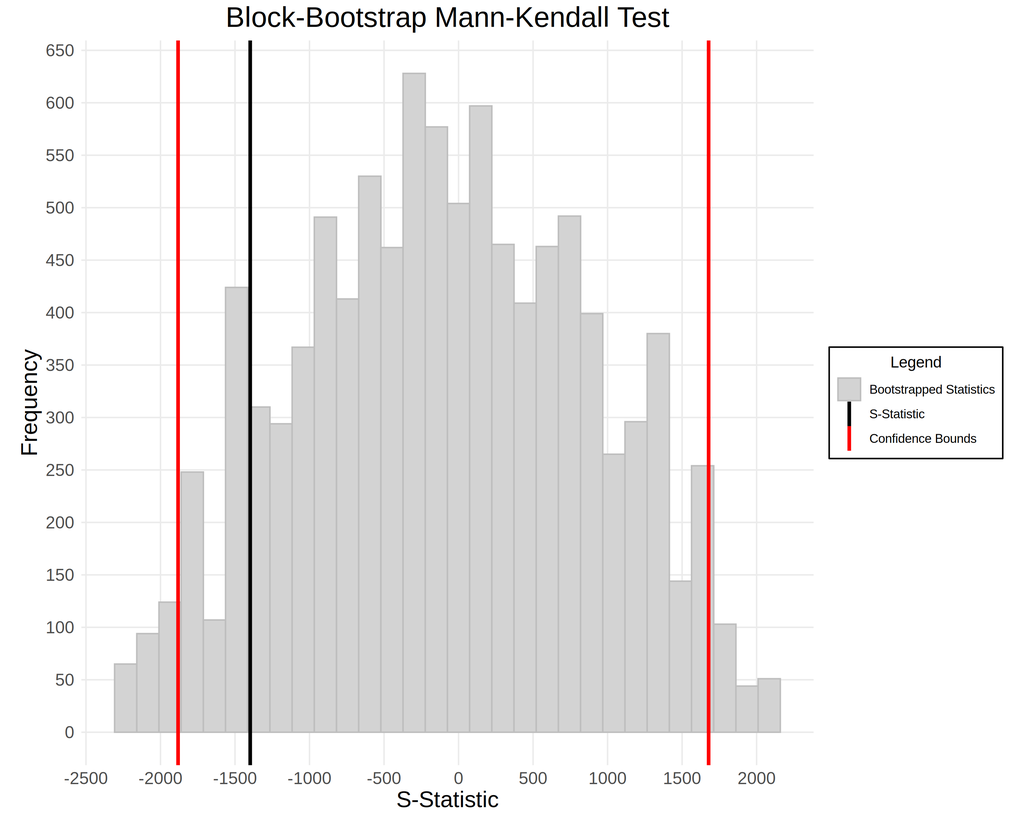